# Tuning text models

이 경우 `mixture`및 의 각 값에 `num_terms`대해 모델은 모든 페널티 값에 적합합니다(이는 이 특정 모델의 기능이며 일반적으로 다른 엔진에는 해당되지 않음). 최상의 매개변수 집합을 선택하기 위해 `extracted`에서 penalty열을 제외할 수 있습니다.

```r
params %>% head()
```

```
## # A tibble: 1 x 4
##   penalty mixture num_terms .config
##     <dbl>   <dbl>     <dbl> <chr>
## 1   0.621    0.01      4096 Preprocessor3_Model028
```

```r
extracted %>%
  dplyr::select(-penalty) %>%
  inner_join(params, by = c("num_terms", "mixture")) %>%
  head()
```

```
## # A tibble: 6 x 7
##   id     num_terms mixture .extracts          .config.x     penalty .config.y
##   <chr>      <dbl>   <dbl> <list>             <chr>           <dbl> <chr>
## 1 Fold01      4096    0.01 <tibble [100 x 2]> Preprocessor~   0.621 Preprocesso~
## 2 Fold01      4096    0.01 <tibble [100 x 2]> Preprocessor~   0.621 Preprocesso~
## 3 Fold01      4096    0.01 <tibble [100 x 2]> Preprocessor~   0.621 Preprocesso~
## 4 Fold01      4096    0.01 <tibble [100 x 2]> Preprocessor~   0.621 Preprocesso~
## 5 Fold01      4096    0.01 <tibble [100 x 2]> Preprocessor~   0.621 Preprocesso~
## 6 Fold01      4096    0.01 <tibble [100 x 2]> Preprocessor~   0.621 Preprocesso~
```

```r
extracted %>%
  dplyr::select(-penalty) %>%
  inner_join(params, by = c("num_terms", "mixture")) %>%
  dplyr::select(-penalty) %>%
  head()
```

```
## # A tibble: 6 x 6
##   id     num_terms mixture .extracts          .config.x              .config.y
##   <chr>      <dbl>   <dbl> <list>             <chr>                  <chr>
## 1 Fold01      4096    0.01 <tibble [100 x 2]> Preprocessor3_Model001 Preprocess~
## 2 Fold01      4096    0.01 <tibble [100 x 2]> Preprocessor3_Model002 Preprocess~
## 3 Fold01      4096    0.01 <tibble [100 x 2]> Preprocessor3_Model003 Preprocess~
## 4 Fold01      4096    0.01 <tibble [100 x 2]> Preprocessor3_Model004 Preprocess~
## 5 Fold01      4096    0.01 <tibble [100 x 2]> Preprocessor3_Model005 Preprocess~
## 6 Fold01      4096    0.01 <tibble [100 x 2]> Preprocessor3_Model006 Preprocess~
```

```r
extracted <-
  extracted %>%
  dplyr::select(-penalty) %>%
  inner_join(params, by = c("num_terms", "mixture")) %>%
  dplyr::select(-penalty)

extracted
```

```
## # A tibble: 300 x 6
##    id     num_terms mixture .extracts          .config.x              .config.y
##    <chr>      <dbl>   <dbl> <list>             <chr>                  <chr>
##  1 Fold01      4096    0.01 <tibble [100 x 2]> Preprocessor3_Model001 Preproces~
##  2 Fold01      4096    0.01 <tibble [100 x 2]> Preprocessor3_Model002 Preproces~
##  3 Fold01      4096    0.01 <tibble [100 x 2]> Preprocessor3_Model003 Preproces~
##  4 Fold01      4096    0.01 <tibble [100 x 2]> Preprocessor3_Model004 Preproces~
##  5 Fold01      4096    0.01 <tibble [100 x 2]> Preprocessor3_Model005 Preproces~
##  6 Fold01      4096    0.01 <tibble [100 x 2]> Preprocessor3_Model006 Preproces~
##  7 Fold01      4096    0.01 <tibble [100 x 2]> Preprocessor3_Model007 Preproces~
##  8 Fold01      4096    0.01 <tibble [100 x 2]> Preprocessor3_Model008 Preproces~
##  9 Fold01      4096    0.01 <tibble [100 x 2]> Preprocessor3_Model009 Preproces~
## 10 Fold01      4096    0.01 <tibble [100 x 2]> Preprocessor3_Model010 Preproces~
## # ... with 290 more rows
```

이제 `unnest()`를 한 번 더 사용하여 원하는 결과를 얻을 수 있다.

```r
extracted <-
  extracted %>%
  unnest(col = .extracts)

extracted
```

```
## # A tibble: 30,000 x 7
##    id     num_terms mixture penalty num_vars .config.x              .config.y
##    <chr>      <dbl>   <dbl>   <dbl>    <int> <chr>                  <chr>
##  1 Fold01      4096    0.01    9.01        0 Preprocessor3_Model001 Preprocesso~
##  2 Fold01      4096    0.01    8.60        1 Preprocessor3_Model001 Preprocesso~
##  3 Fold01      4096    0.01    8.21        2 Preprocessor3_Model001 Preprocesso~
##  4 Fold01      4096    0.01    7.84        2 Preprocessor3_Model001 Preprocesso~
##  5 Fold01      4096    0.01    7.48        3 Preprocessor3_Model001 Preprocesso~
##  6 Fold01      4096    0.01    7.14        3 Preprocessor3_Model001 Preprocesso~
##  7 Fold01      4096    0.01    6.82        4 Preprocessor3_Model001 Preprocesso~
##  8 Fold01      4096    0.01    6.51        6 Preprocessor3_Model001 Preprocesso~
##  9 Fold01      4096    0.01    6.21        7 Preprocessor3_Model001 Preprocesso~
## 10 Fold01      4096    0.01    5.93        7 Preprocessor3_Model001 Preprocesso~
## # ... with 29,990 more rows
```

이 결과를 resample별로 그래프를 그려보자.

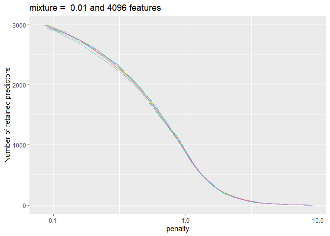

```r
extracted %>%
  ggplot(aes(x = penalty, y = num_vars)) +
  geom_line(aes(group = id, col = id), alpha = 0.5) +
  labs(x = "penalty", y = "Number of retained predictors",
       title = paste("mixture = ", params$mixture, "and", params$num_terms, "features")) +
  scale_x_log10() +
  theme(legend.position = "none")
```

이러한 결과는 더 많은 최적화가 수행된 경우 `penalty` 범위 선택을 안내하는 데 도움이 될 수 있습니다.

**END**